# Math 189: Time Series IV

# Forecasting

- Given a time series sample $X_t$ for times $1 \leq t \leq n$, we want to predict $X_{n+1}$. This is the *forecasting* problem.
- The multi-step ahead forecasting problem is to predict $X_{n+h}$ for $h \geq 1$. When $h=1$, this is one-step ahead forecasting.

## One-Step Ahead for AR(p)

- Suppose we have fitted an AR(p) model to the sample.
- This means the mean zero process $Y_t = X_t - {\mathbb E} [ X_t ]$ satisfies
  $$Y_t = \sum_{j=1}^p \phi_j \, Y_{t-j} + Z_t,$$
  where $\{ Z_t \}$ is i.i.d. The coefficients $\phi_1, \ldots, \phi_p$ are the model parameters.
- The forecast formula is
  $$\widehat{Y}_{n+1} = \sum_{j=1}^p \phi_j \, Y_{n+1-j}.$$
  Since the coefficients are unknown, we must estimate them and plug in.

```r
pop <- read.table("USpop.dat")
pop <- ts(pop, start = 1901)
mu <- mean(pop[1:90])
data <- pop[1:90] - mu
ar_mdl <- ar.ols(data)
ar_mdl$ar[,1,1]
```

```
## [1]  1.8825020 -0.8817316
```

```r
forecast <- mu + sum(ar_mdl$ar[,1,1]*data[90:(91-ar_mdl$order)])
c(forecast,pop[91])
```

```
## [1] 251870165 252153092
```

## Multi-Step Ahead for AR(p)

- For the AR(p) we want to forecast $h$ steps ahead.
- We can recursively to one-step ahead forecasts:
1. Given the $h-1$-step ahead forecast, append to the end of the series
2. Now apply the $1$-step ahead forecast formula

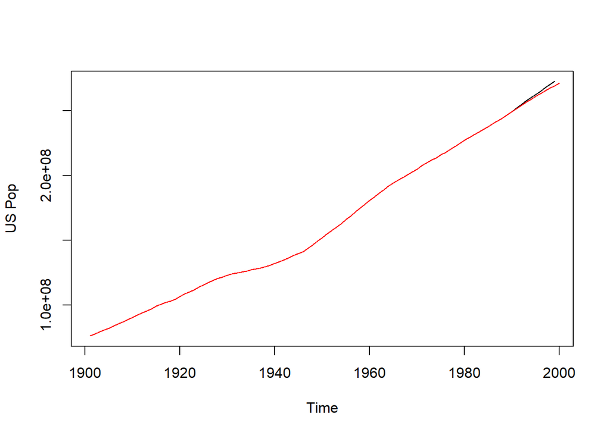

```r
data <- pop[1:90]
forecasts <- data
ar_mdl <- ar.ols(data)
for(h in 1:10)
{
  nn <- length(forecasts)
  forecast <- sum(ar_mdl$ar[,1,1]*forecasts[nn:(nn+1-ar_mdl$order)])
  forecasts <- c(forecasts,forecast)
}
plot(pop,ylab="US Pop")
lines(ts(forecasts,start=1901),col=2)
```

## More!!

- Quantify forecast uncertainty (yes!)
- More complicated models (yes!)
- Handle missing values!
- Add multiple variables (multiple time series)!
- Requires a whole time series course (2-3 quarters) to explore.

# Volatile Time Series

- Some time series have variability that changes over time; this is different from time series with changing mean (trends).
- Recall the Dow Log Returns.

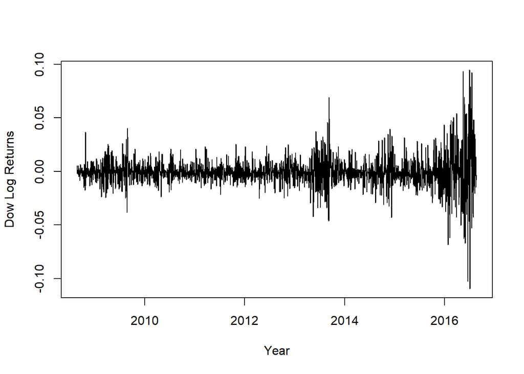

```r
dow <- read.table("dow.dat")
dow <- ts(dow,start=c(2008,164),frequency=252)
dow.diff <- diff(log(dow[,1]))
plot(dow.diff,xlab="Year",ylab="Dow Log Returns")
```

## Autoregressive Conditional Heteroscedasticity

- The so-called ARCH (Autoregressive Conditional Heteroscedasticity) Process models such data:
  $$\begin{align*}
  X_t & = \sigma_t \, Z_t \\
  \sigma^2_t & = a_0 + a_1 \, X_{t-1}^2.
  \end{align*}$$
  Note that the *volatility* $\sigma_t^2$ depends on the square of previous observation.
- This is a *nonlinear* time series, which means it cannot be expressed as a linear filter acting on i.i.d. inputs.
- We can generalize this to an ARCH(p) process:
  $$\begin{align*}
  X_t & = \sigma_t \, Z_t \\
  \sigma^2_t & = a_0 + a_1 \, X_{t-1}^2 + \ldots + a_p \, X_{t-p}^2.
  \end{align*}$$
  The coefficients $a_0, a_1, \ldots, a_p$ are the ARCH parameters.
- We assume that the volatility $\sigma_t^2$ is random, but has constant mean ${\mathbb E} [ \sigma_t^2]$. This implies that
  $${\mathbb E} [ \sigma^2 ] = \frac{a_0}{1 - \sum_{j=1}^p a_j}.$$
  So it is necessary that $a_0 > 0$ and $0 \leq \sum_{j=1}^p a_j < 1$.

## Fitting an ARCH(p)

- We can fit log returns by OLS, by regressing the squared data on its past lags. This is crude, because it replaces $\sigma_t^2$ by $X_t^2$ to do the regression.
- A better method is to do maximum likelihood estimation…
- We can decide on order $p$ using AIC, like for AR processes.

```r
sigt <- dow.diff^2
ar_mdl <- ar.ols(sigt)
ar_mdl$order
```

```
## [1] 33
```

```r
ar_mdl$ar[,1,1]
```

```
##  [1] -0.049074019  0.254658006 -0.018178157  0.060558268  0.163176206
##  [6]  0.094168798  0.091793153  0.022906070  0.070935220  0.064590250
## [11]  0.158067568  0.095387720 -0.054480987 -0.177477265 -0.051236280
## [16] -0.022945713  0.016111743  0.034260026 -0.033425729  0.050050253
## [21]  0.064730682 -0.090938781  0.046554176  0.013180457 -0.039928894
## [26]  0.017116462  0.146210029  0.073741457 -0.037706735 -0.084386604
## [31] -0.008761254  0.058862565 -0.055963312
```

- The problem here is that the coefficient estimates are not positive.
- We can use a variety of packages.

```r
library(tseries)
arch.fit <- garch(dow.diff, order = c(0, ar_mdl$order))
```

[output not shown]

[output cut: 117 more lines]

```r
round(arch.fit$coef,digits=6)
```

```
##       a0       a1       a2       a3       a4       a5       a6       a7
## 0.830954 0.014075 0.014343 0.001925 0.002709 0.009820 0.016534 0.068915
##       a8       a9      a10      a11      a12      a13      a14      a15
## 0.005131 0.006735 0.018981 0.035821 0.007875 0.090885 0.014331 0.005893
##      a16      a17      a18      a19      a20      a21      a22      a23
## 0.029746 0.027448 0.006590 0.032904 0.006941 0.006371 0.009528 0.004360
##      a24      a25      a26      a27      a28      a29      a30      a31
## 0.005363 0.010855 0.001241 0.007822 0.000000 0.003797 0.014743 0.004810
##      a32      a33
## 0.011170 0.046051
```

# Volatility Filtering

- ARCH models and their generalizations do not *fully* capture volatility clustering and *fat tails* (i.e., extreme observations).
- Considering a moving average of squared returns:
  $$\Pi (B) X_t^2 = \sum_{j= -\infty}^{\infty} \pi_j \, X_{t-j}^2$$
  is a *volatility filter*, if all $\pi_j \geq 0$.
- A volatility filter can be causal, symmetric, etc.
- We consider estimating volatility $\sigma_t^2 = {\mathbb E} [ X_t^2]$ by a volatility filter, just like we did for estimating the mean $\mu_t = {\mathbb E} [ X_t]$:
  $$\widehat{\sigma}_t^2 = \Pi (B) X_t^2.$$
  Same bias-variance trade-off applies as with mean estimation.

## Example: Volatility Filtering of Dow

- Consider the volatility filter $\pi_j = 1/11$ for $|j| \leq 5$.
- Observe the increased volatility in more recent years.

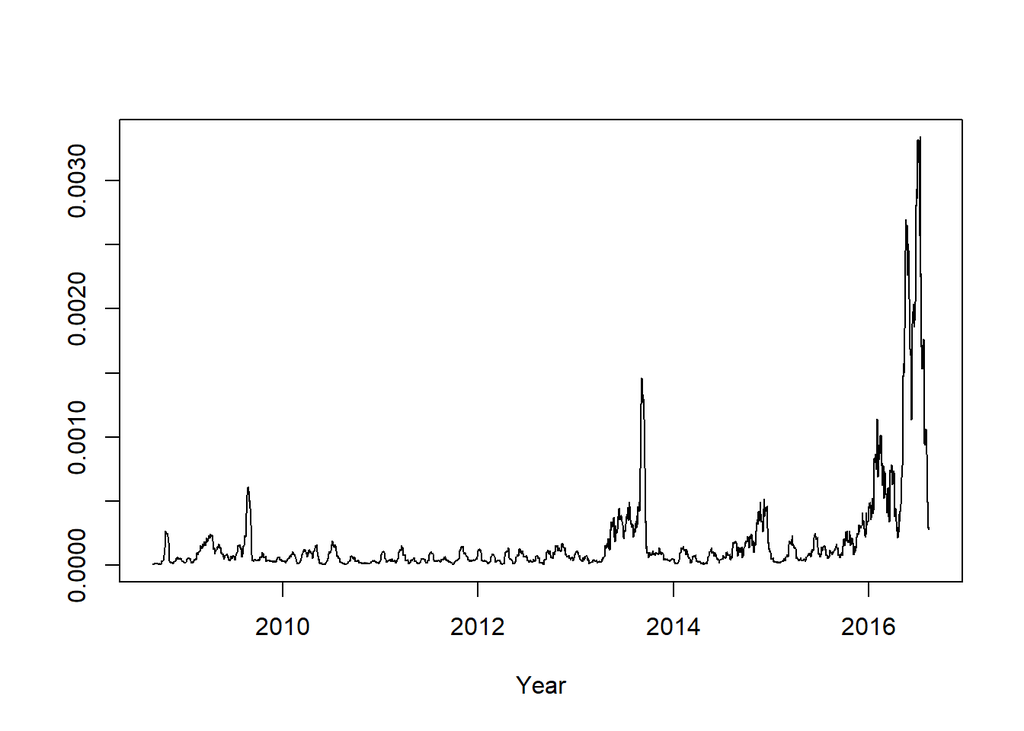

```r
p <- 5
dow.vol <- filter(dow.diff^2,rep(1,2*p+1)/(2*p+1),method="convolution",sides=2)
plot(dow.vol,xlab="Year",ylab="",lwd=1)
```

## The NoVaS Transformation

- When $\Pi (B)$ is causal, then $\widehat{\sigma}^2_t$ depends only on present and past data.
- Then we can divide out by the (square root) volatility, getting a *pseudo-residual*:
  $$W_t = \frac{ X_t}{ \widehat{\sigma}_t}.$$
  This is called the *Normalizing and Variance Stabilizing* (NoVaS) transform.
- Due to Professor D.N. Politis, one of our own!
- NoVaS is unbiased if $\Pi (1) = 1$, i.e., the sum of all coefficients equals one.

## NoVaS Methodology

- The idea is to choose a NoVaS transform $\Pi (B)$ such that $\{ W_t \}$ is close to i.i.d. Gaussian.
- We want light tails and no serial correlation.
- We can search over volatility filters to find pseudo-residuals with this property.

### NoVaS with Simple Weights

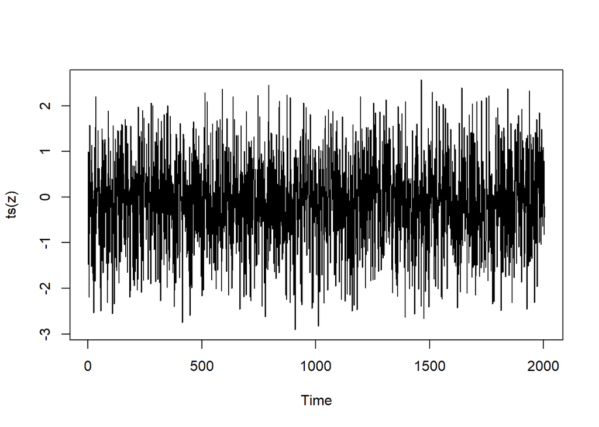

```r
p <- 9
psi <- rep(1,p+1)/(p+1)
n <- length(dow.diff)
dow.vol <- filter(dow.diff^2,psi,method="convolution",sides=1)[(p+1):n]
z <- dow.diff[(p+1):n]/sqrt(dow.vol)
m <- length(z)
plot(ts(z))
```